# GLM Assignment

### **Objective**: Create a report using Markdown that presents code, results, and summarized findings that evaluates a hypothesis regarding the occurrence of lynx (*Lynx canadensis*) in the southern Rocky Mountains.

### **Overview**

A colleague sampled the occurrence (0 or 1) of Canada lynx at 75 grid cells using camera-traps. They are interested in you helping fit a model to estimate the occurrence probability of lynx and evaluate their hypothesis.

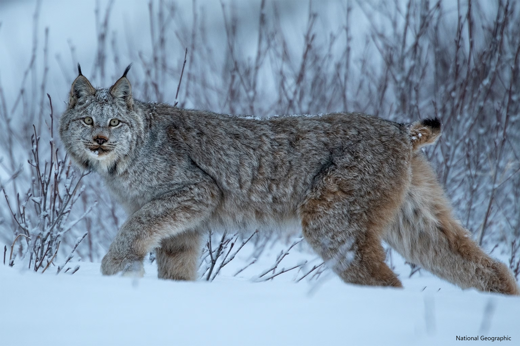

### Data and Hypothesis

A colleague used camera traps to sample whether a lynx was present (1) or assumed absent (0) at each grid cell or ‘site’ (`y`) during the winter (December to February); we will assume there are no false-positives or false-negatives in these data. They designed the sampling and site selection such they had variation in two important covariates: the distance the camera was from a road (`dist.road`) and the percentage of forest cover (`cover`). Their hypothesis is that lynx will avoid human activity by occurring further from roads when they are not under cover, but will occur near roads that are under cover as they are able to remain hidden.

#### *To do*

Fit the data (`lynx.data.csv`) using a single model that allows you to evaluate the hypothesis of your colleague.

- interpret coefficients (what they mean exactly)
- make prediction plot(s)
- summarize results and evaluate hypothesis support or not
- provide any nuance in findings that are outside of the core hypothesis
- indicate how you used AI to accomplish this lab